# Programando IA com R

14IA - Vitor Stipanich de Santiago | RM 339165

###### Esse notebook foi desenvolvido visando o conteúdo coberto pelas aulas de R do professor Elthon, ministradas no curso de I.A.

# O que é o R?

O R é uma linguagem muito potente por ser dinâmica e *data-driven* . É uma linguagem baseada fortemente em **vetores, matrizes e listas**, já que são tipos de dados utilizados fortemente em análises estatísticas.

No console R, podemos digitar expressões e elas são avaliadas em real time:

```r
numeros = 1:10
print(numeros)
```

```
##  [1]  1  2  3  4  5  6  7  8  9 10
```

Neste trecho acima estou criando uma lista que vai de 1 até 10, de forma dinâmica através da função (que parece até um operador pela notação!) ** : ** . Temos diversas maneiras de operar em cima dessas estruturas. Não precisamos realizar loops com condicionais embutidas para filtrar elementos de um vetor:

```r
pares = numeros[numeros %% 2 == 0]
print(pares)
```

```
## [1]  2  4  6  8 10
```

E isso não se aplica apenas ao *mod*: podemos executar diferentes operadores ou funções que produzam resultados booleanos para filtrar os elementos dos vetores. Isso nos permite realizar diversas operações em grandes datasets, facilitando o dia a dia do cientista de dados.

Podemos criar matrizes? Podemos!

```r
minha.matriz <- matrix(data=seq(1, 1000), nrow=100, ncol=10)
head(minha.matriz, 5)
```

```
##      [,1] [,2] [,3] [,4] [,5] [,6] [,7] [,8] [,9] [,10]
## [1,]    1  101  201  301  401  501  601  701  801   901
## [2,]    2  102  202  302  402  502  602  702  802   902
## [3,]    3  103  203  303  403  503  603  703  803   903
## [4,]    4  104  204  304  404  504  604  704  804   904
## [5,]    5  105  205  305  405  505  605  705  805   905
```

Observe que o ponto (“.”) no nome da variável não indica o atributo ou propriedade de um objeto, mas é um caractere comum! O nome da matriz que eu criei então é “minha.matriz”, e não um objeto chamado “minha” com uma propriedade “matriz” dentro.

O R possui, nativamente, algumas funções para plotar gráficos e desenhar relações. Na prática, existem bibliotecas que fazem isso de maneira mais fácil (ou até mesmo iterativa) pra você. Vamos ver um simples scatterplot em R:

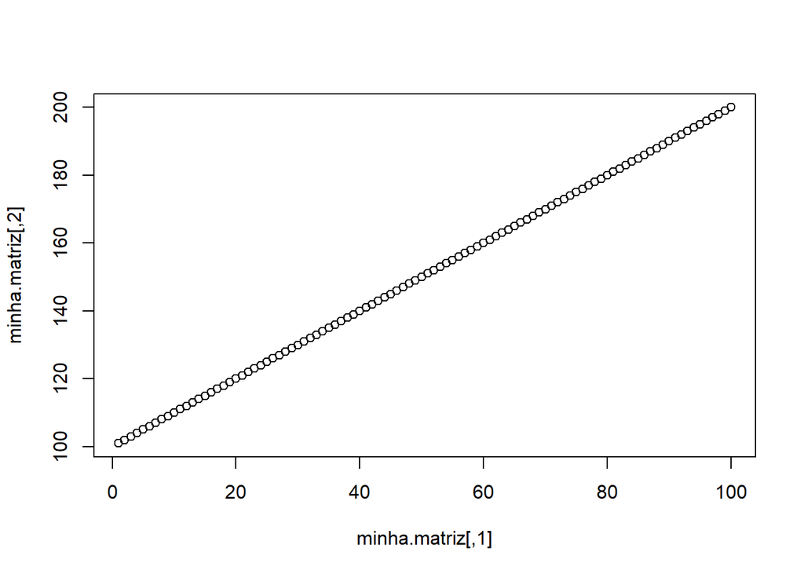

```r
plot(minha.matriz)
```

Apenas chamando a função *plot* com a matriz criada o R já tenta assumir diversas coisas pra facilitar pra você. Veja que a relação plotada foi de minha.matriz[,1] e minha.matriz[,2], já que não informamos nenhum valor específico para X e Y, cor dos pontos, linhas, etc. Vamos fazer isso?

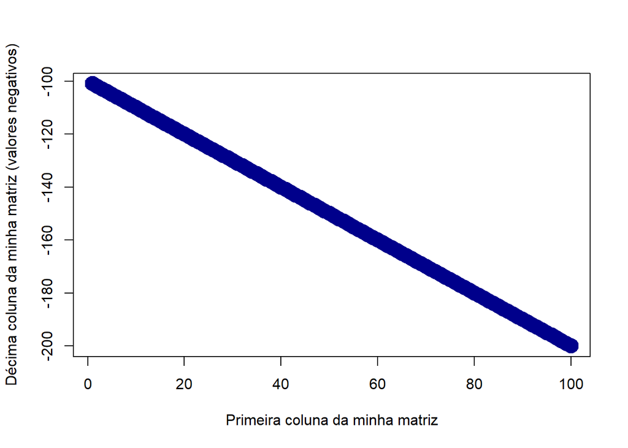

```r
plot(x = minha.matriz[,1],
     y = minha.matriz[,2]*-1,
     type = "b",
     xlab = "Primeira coluna da minha matriz",
     ylab = "Décima coluna da minha matriz (valores negativos)",
     col="darkblue",
     lwd=10)
```

Nessa versão de plot, especifiquei os valores que quero pra X e Y (note que até modifiquei), os nomes, a largura e cor dos pontos e mais. O R nativo é recheado de funções para trabalhar o dataset e plotar gráficos, sendo uma excelente ferramenta para análise de dados. Vamos ver abaixo algumas operações utilizando tanto R nativo quanto pacotes da comunidade.

Mas não vamos ficar apenas em vetores numéricos e listas mockadas…

# Operações em datasets

Ao invés de criar vetores numéricos e datasets simples para mostrar um pouco a linguagem, vamos partir para algo mais divertido. Irei utilizar [esse dataset de Pokemon](https://www.kaggle.com/rounakbanik/pokemon) para mostrar um pouco do que o R pode fazer, junto de pacotes que são amplamente utilizados na indústria.

Primeiro, vamos carregá-lo:

```r
pokemon = read.csv("C:/Users/Vitor Stipanich/Documents/AI&ML/R/programando IA com R/pokemon.csv", stringsAsFactors=TRUE)
```

O comando acima, como é possível imaginar, lê o arquivo indicado no path como CSV, e você ainda pode passar diversos parametros para customizar a leitura. Mas você mesmo já deve ter imaginado que seria problemático deixar o path fixo sem antes poder disponibilizar uma opção de baixar ou salvar o arquivo em um diretório diferente.  
Vamos então pegar da web!  
Para isso, vou definir uma função que faz o download de um arquivo por URL:

```r
baixar.arquivo.data <- function(file.url, file.local = NA, downloaded.file.name=NA) {
  if (is.na(file.local)) {
    file.local = file.path('./data', basename(file.url))
  } else {
    if (is.na(downloaded.file.name)) {
      file.local = file.path(file.local, basename(file.url))
    } else {
      file.local = file.path(file.local, downloaded.file.name)
    }
  }
  download.file(url = file.url, destfile = file.local, mode='wb', method='libcurl')
}

baixar.arquivo.data(file.url="https://gist.githubusercontent.com/vitorhead/133233cd37cc6af8d4e63582bf82e690/raw/82304c9dae9d5e944680d1bca97d883dbf386a7c/pokemon.csv",
                    file.local=paste(getwd(), "/data", sep=""),
                    downloaded.file.name="pokemon.csv")

# Para utilizarmos futuramente na leitura
downloaded.file.path = paste(getwd(), "data", "pokemon.csv", sep="/")
```

Nesse trecho acima criamos uma função com tres parâmetros, o segundo opcional para o programador salvar em um path específico. O terceiro parametro também é opcional, possibilitando que o arquivo baixado assuma outro nome para ser salvo. Agora podemos trabalhar com arquivos pela web e não ter desculpas de “na minha máquina funciona!!”  
Agora sim, vamos ler o arquivo!

```r
pokemon = read.csv(downloaded.file.path, stringsAsFactors=TRUE, encoding="UTF-8")

pokemon %>%
  head(20) %>%
  select(name, type1, type2, hp, attack, defense)
```

|  | name | type1 | type2 | hp | attack | defense |
| --- | --- | --- | --- | --- | --- | --- |
| 1 | Bulbasaur | grass | poison | 45 | 49 | 49 |
| 2 | Ivysaur | grass | poison | 60 | 62 | 63 |
| 3 | Venusaur | grass | poison | 80 | 100 | 123 |
| 4 | Charmander | fire |  | 39 | 52 | 43 |
| 5 | Charmeleon | fire |  | 58 | 64 | 58 |
| 6 | Charizard | fire | flying | 78 | 104 | 78 |
| 7 | Squirtle | water |  | 44 | 48 | 65 |
| 8 | Wartortle | water |  | 59 | 63 | 80 |
| 9 | Blastoise | water |  | 79 | 103 | 120 |
| 10 | Caterpie | bug |  | 45 | 30 | 35 |

[output cut: 10 more lines]

# Explorando

Temos um dataset com os 801 pokemon e diversas informações sobre os status (ataque, vida, defesa, velocidade, etc), tipos, habilidades e outros. Vamos ver o que podemos extrair desses dados!

#### Quantos pokemon existem por geração?

```r
pokemon %>%
  group_by(generation) %>%
  summarize(quantidade=n())
```

| generation | quantidade |
| --- | --- |
| 1 | 151 |
| 2 | 100 |
| 3 | 135 |
| 4 | 107 |
| 5 | 156 |
| 6 | 72 |
| 7 | 80 |

#### Podemos separar os pokemon por tipo primário (type1)?

```r
pokemon %>%
  group_by(type1) %>%
  summarize(quantidade=n())
```

| type1 | quantidade |
| --- | --- |
| bug | 72 |
| dark | 29 |
| dragon | 27 |
| electric | 39 |
| fairy | 18 |
| fighting | 28 |
| fire | 52 |
| flying | 3 |
| ghost | 27 |
| grass | 78 |

[output cut: 8 more lines]

#### Tabelas não! Vamos fazer um gráfico pra visualizar melhor a divisão por tipos:

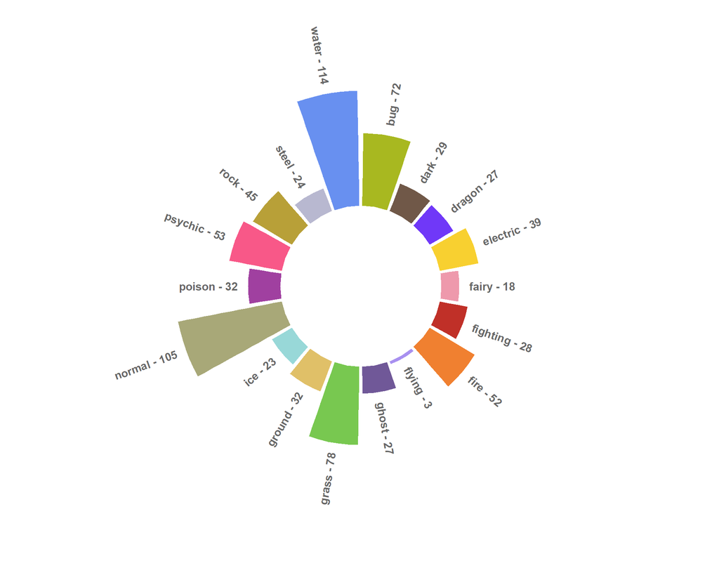

```r
# Primeiro vamos definir uma matriz que guarda o nome do tipo e uma cor para representa-lo
# Assim nosso grafico fica bonito :)
type_colors <-
  matrix(data = c(
    c("Bug", "#A8B820"),
    c("Dark", "#705848"),
    c("Dragon", "#7038F8"),
    c("Electric", "#F8D030"),
    c("Fairy", "#EE99AC"),
    c("Fighting", "#C03028"),
    c("Fire", "#F08030"),
    c("Flying", "#A890F0"),
    c("Ghost", "#705898"),
    c("Grass", "#78C850"),
    c("Ground", "#E0C068"),
    c("Ice", "#98D8D8"),
    c("Normal", "#A8A878"),
    c("Poison", "#A040A0"),
    c("Psychic", "#F85888"),
    c("Rock", "#B8A038"),
    c("Steel", "#B8B8D0"),
    c("Water", "#6890F0")), nrow = 18, ncol = 2, byrow=TRUE)


qtd.type <- pokemon %>%
  group_by(type1) %>%
  summarize(quantidade=n())


# angulos pra posicionar
labels.type.plot <- qtd.type
number_of_bar <- nrow(labels.type.plot)
angle <-  90 - 360 * (seq(1,length(labels.type.plot$type1))-0.5) / number_of_bar

labels.type.plot$hjust<-ifelse( angle < -90, 1, 0)

# girar o angulo pra deixar o texto legivel
labels.type.plot$angle<-ifelse(angle < -90, angle+180, angle)

ggplot(qtd.type, aes(x=as.factor(type1), y=quantidade)) +
  geom_bar(stat="identity", fill=type_colors[1:18,2]) +
  ylim(-80,170) + # valor negativo = circulo interno, positivo = tamanho de cada barra
  geom_text(data=labels.type.plot, aes(x=type1, y=quantidade+10, label=paste(type1, quantidade, sep=" - "), hjust=hjust), color="black", fontface="bold",alpha=0.6, size=4, angle=labels.type.plot$angle) +
  theme_minimal() +
  theme(
    axis.text = element_blank(),
    axis.title = element_blank(),
    panel.grid = element_blank(),
    plot.margin = unit(rep(-1,4), "cm")
  ) +
  coord_polar(start = 0)
```

#### Qual o pokemon do tipo grama que tem o maior ataque?

```r
pokemon %>%
  filter(type1 == "grass") %>%
  arrange(desc(attack)) %>%
  select(name, generation, attack, hp, defense, type1, type2, is_legendary) %>%
  head(1)
```

|  | name | generation | attack | hp | defense | type1 | type2 | is_legendary |
| --- | --- | --- | --- | --- | --- | --- | --- | --- |
| 1 | Kartana | 7 | 181 | 59 | 131 | grass | steel | 1 |

O pokemon com maior ataque é Kartana. Mas é um pokemon lendário, assim como visto na última coluna.

#### Podemos descobrir o pokemon mais rápido, porém dessa vez fazendo distinção dos lendários e não lendários?

```r
pokemon %>%
  group_by(is_legendary) %>%
  top_n(1, speed) %>%
  select(name, generation, attack, hp, defense, speed, type1, type2, is_legendary)
```

| name | generation | attack | hp | defense | speed | type1 | type2 | is_legendary |
| --- | --- | --- | --- | --- | --- | --- | --- | --- |
| Ninjask | 3 | 90 | 61 | 45 | 160 | bug | flying | 0 |
| Deoxys | 3 | 95 | 50 | 90 | 180 | psychic |  | 1 |

#### Dividindo os pokemon por tipagem primária (type1), qual é o mais pesado (kg) de cada tipo?

[figure not shown]

```r
pokemon %>%
  group_by(type1) %>%
  top_n(1, weight_kg) %>%
  select(name, type1, weight_kg) %>%
      ggplot(aes(x=type1, y=weight_kg)) +
      geom_col(aes(fill=type1), position = "dodge", width=0.5) +
      theme(axis.text.x=element_text(angle = 35, hjust = 1)) +
      labs(x="Tipo", y="Peso (kg)", fill="Tipos") +
      scale_fill_manual(values=type_colors[,2]) +
      geom_text(
        aes(label = name),
        position = position_stack(vjust = 0.5),
        angle=90,
        colour="white")
```

## Batalhas

Os jogos pokemon são muito famosos por possibilitar a chance de construir um time com os seus favoritos e batalhar vários treinadores durante a sua jornada até a liga. Durante uma batalha, os pokemon utilizam ataques físicos ou especiais para infligir dano no seu oponente. Cada ataque tem um tipo, e os tipos possuem vantagens e desvantagens entre si.  
Nesse dataset, as colunas **against_XXXX** (onde XXXX é o tipo) representam o quão efetivo aquele tipo é sobre o pokemon correspondente.  
**Esse dataset é bem simples; não contém informações sobre ataques nem informações sobre se o pokemon é o último estágio evolucionário de sua linha. Iremos fazer operações simples apenas visando o ferramental do R!**

Será que conseguimos descobrir, por exemplo, qual(is) seria(m) uma boa escolha para enfrentar o pokemon Hypno? Vamos começar recuperando apenas ele do dataset:

```r
hypno = pokemon %>% filter(name == "Hypno")
```

Agora, para descobrir as fraquezas, vamos recuperar todas que sejam maior que 1.0 (dano neutro):

```r
fraquezas.hypno = hypno %>%
                  select(contains("against_")) %>%
                  select_if(~any( . > 1.0))
fraquezas.hypno
```

| against_bug | against_dark | against_ghost |
| --- | --- | --- |
| 2 | 2 | 2 |

Vamos então recuperar uma lista de pokemon que contenham um ou mais dessas tipagens como type1 ou type2:

```r
# Removendo o agaisnt para utilizar como filtro
fraquezas.hypno.formatado =
  map(colnames(fraquezas.hypno), function(colname) { str_replace(colname, "against_", "") })

oponentes.hypno = pokemon %>%
                      filter(is.element(type1, fraquezas.hypno.formatado) | is.element(type2, fraquezas.hypno.formatado) ) %>%
                      select(name, type1, type2, generation, attack, defense, hp) %>%
                      arrange(desc(attack))
```

```r
#utils
vetor.atributos <- function() {
  return(c("attack", "defense", "hp", "speed", "sp_attack", "sp_defense"))
}

print.datatable.treinador <- function(treinador, nome) {
  datatable(treinador,
            caption = htmltools::tags$caption(
              style = 'caption-side: top; text-align: center; font-size: 20pt;',
              nome
            ),
            class = 'cell-border stripe',
            rownames = FALSE,
            options = list(dom = 't'),
            filter = list(position = "none"))
}
```

Neste seção acima estou definindo duas funções utilitárias para usarmos daqui pra frente nas próximas análises. O intuito da primeira é agregar algumas colunas em um vetor para ficar mais fácil de chamar no select() do pacote dplyr.  
Já a segunda função nos auxilia a printar um datatable do pacote DT com uma estética mais definida.

## Criando times

Outra situação bem comum no jogo é encontrar treinadores especializados em tipos ou temáticas de pokemon.  
Com um pouco de criatividade e esse dataset, podemos criar situações parecidas:

```r
treinador.joey <- pokemon %>%
                    filter(type1 == "water" &
                           (attack >= 100 | sp_attack >= 100) &
                           speed >= 75 &
                           is_legendary == 0) %>%
                    select(name, type1, type2, generation, vetor.atributos(), against_bug:against_water) %>%
                    sample_n(6)
print.datatable.treinador(treinador.joey[,1:10], 'Treinador Joey')
```

| name | type1 | type2 | generation | attack | defense | hp | speed | sp_attack | sp_defense |
| --- | --- | --- | --- | --- | --- | --- | --- | --- | --- |
| Sharpedo | water | dark | 3 | 140 | 70 | 70 | 105 | 110 | 65 |
| Milotic | water |  | 3 | 60 | 79 | 95 | 81 | 100 | 125 |
| Starmie | water | psychic | 1 | 75 | 85 | 60 | 115 | 100 | 85 |
| Feraligatr | water |  | 2 | 105 | 100 | 85 | 78 | 79 | 83 |
| Bruxish | water | psychic | 7 | 105 | 70 | 68 | 92 | 70 | 70 |
| Kingler | water |  | 1 | 130 | 115 | 55 | 75 | 50 | 50 |

No código acima, criei a variável representando o treinador Joey, que gosta de pokemon do tipo água.  
Os pokemon de Joey são fortes e rápidos (por isso o filtro no ataque, ataque especial e velocidade) e ele também não possui pokemon lendários.

Vamos agora criar outro treinador, dessa vez não se restringindo os tipos:

```r
treinador.steve <- pokemon %>%
                      filter(hp >= 100 & defense >= 110 & is_legendary == 0) %>%
                      select(name, type1, type2, generation, vetor.atributos(), against_bug:against_water) %>%
                      sample_n(6)
print.datatable.treinador(treinador.steve[,1:10], 'Treinador Steve')
```

| name | type1 | type2 | generation | attack | defense | hp | speed | sp_attack | sp_defense |
| --- | --- | --- | --- | --- | --- | --- | --- | --- | --- |
| Garchomp | dragon | ground | 4 | 170 | 115 | 108 | 92 | 120 | 95 |
| Rhydon | ground | rock | 1 | 130 | 120 | 105 | 40 | 45 | 45 |
| Tangrowth | grass |  | 4 | 100 | 125 | 100 | 50 | 110 | 50 |
| Audino | normal |  | 5 | 60 | 126 | 103 | 50 | 80 | 126 |
| Swampert | water | ground | 3 | 150 | 110 | 100 | 70 | 95 | 110 |
| Tyranitar | rock | dark | 2 | 164 | 150 | 100 | 71 | 95 | 120 |

Será que é possível criarmos uma função que receba o nome de um pokemon e descubra um bom parceiro para uma batalha em dupla, levando em consideração suas fraquezas e seus atributos base?

```r
check.pokemon <- function(nome) {
  return(any(pokemon$name == nome))
}

find.pokemon.weakness <- function(nome) {
   pokemon.escolhido <- pokemon[pokemon$name == nome,]
   fraquezas <- pokemon.escolhido %>%
                  select(contains("against_")) %>%
                  select_if(~any( . > 1.0)) %>%
                  colnames()
   return(fraquezas)
}

find.best.partner.old <- function(nome, legendary = NA) {
  if (check.pokemon(nome)) {
    weakness.pkmn <- find.pokemon.weakness(nome)
    chosen.pkmn <- pokemon[pokemon$name == nome,]
    partner <- pokemon %>%
                filter(!!as.symbol(weakness.pkmn) < 1.0 &
                        base_total >= (chosen.pkmn$base_total * 0.5) &
                        name != chosen.pkmn$name) %>% # situations like Rayquaza
                arrange(desc(base_total))

    if(!is.na(legendary) & !legendary) {
      partner <- partner %>% filter(is_legendary == 0) %>% head(1)
    } else {
      partner <- head(partner, 1)
    }
    return(partner)
  }
}

# achar pkmn que dao > 1.0 em weakness.pkmn
# pkmn que tem type1 ou type2 que tem o maior somatoria de weakness.pkmn
find.best.partner <- function(nome, legendary = NA) {
  if (check.pokemon(nome)) {
    weakness.pkmn <- find.pokemon.weakness(nome)
    weakness.as.sum <- paste(weakness.pkmn, collapse = "+")
    chosen.pkmn <- pokemon[pokemon$name == nome,]
    partner <- pokemon %>%
                filter(base_total >= (chosen.pkmn$base_total * 0.5) &
                        name != chosen.pkmn$name) %>% # situations like Rayquaza
                mutate(sum.weakness = eval(parse(text=weakness.as.sum)) ) %>%
                arrange(sum.weakness, desc(base_total))

    if(!is.na(legendary) & !legendary) {
      partner <- partner %>% filter(is_legendary == 0) %>% head(1)
    } else {
      partner <- head(partner, 1)
    }

    # drop the mutated column before returning
    partner <- select(partner, -sum.weakness)
    return(partner)
  }
}


find.best.partner("Aerodactyl", legendary=FALSE) %>%
  select(name, type1, type2, generation, base_total, abilities) %>%
  print.datatable.treinador(paste("Um bom parceiro para o Aerodactyl é o", .$name, sep=" "))
```

| name | type1 | type2 | generation | base_total | abilities |
| --- | --- | --- | --- | --- | --- |
| Magnezone | electric | steel | 4 | 535 | ['Magnet Pull', 'Sturdy', 'Analytic'] |

E se agora tentarmos montar um time inteiro, focando apenas no pokemon informado?

```r
target.pkmn.name <- "Aerodactyl"

my.team <- pokemon[pokemon$name == target.pkmn.name, ]
while (nrow(my.team) < 6) {
  last.pkmn.name <- tail(my.team, 1)$name
  next.partner <- find.best.partner(last.pkmn.name, legendary=FALSE)
  pokemon <- pokemon %>% filter(name != last.pkmn.name)
  my.team <- rbind(my.team, next.partner)
}

# run this again to load the dataset
pokemon = read.csv(downloaded.file.path, stringsAsFactors=TRUE, encoding="UTF-8")

my.team %>%
  select(name, type1, type2, generation, base_total, abilities) %>%
  print.datatable.treinador("Time gerado")
```

| name | type1 | type2 | generation | base_total | abilities |
| --- | --- | --- | --- | --- | --- |
| Aerodactyl | rock | flying | 1 | 615 | ['Rock Head', 'Pressure', 'Unnerve'] |
| Magnezone | electric | steel | 4 | 535 | ['Magnet Pull', 'Sturdy', 'Analytic'] |
| Salamence | dragon | flying | 3 | 700 | ['Intimidate', 'Moxie'] |
| Mawile | steel | fairy | 3 | 480 | ['Hyper Cutter', 'Intimidate', 'Sheer Force'] |
| Gyarados | water | flying | 1 | 640 | ['Intimidate', 'Moxie'] |
| Steelix | steel | ground | 2 | 610 | ['Rock Head', 'Sturdy', 'Sheer Force'] |